# Unlock Unstructured Data

2016-12-14

## What I do?

## Outline

- What?
- Why?
- Where?
- Automatic data pipeline
- Remote Computing
- Security
- Data access for data scientist
- Data analysis
- Visualization and Report
- Cross functional collaboration

## What is Unstructured Data?

[figure not shown]

## Why?—It is everywhere

- Open government data
- Search engine data
- Services that track social behavior
- Social media data

## Why?—Practical arguments

- Social media is impactful! [Amusing Ourselves to Death: Public Discourse in the Age of Show Business (1985)]
  - "the medium is the message"
  - "the medium is the metaphor"
  - "the form excludes the content"
- Financial resources are sparse
- … and so is our time
- Reproducibility

## Where to get the data?

- API: Twitter/Google/Wikipedia…
- Webpage: Forum, Reviews

## Summary of packages

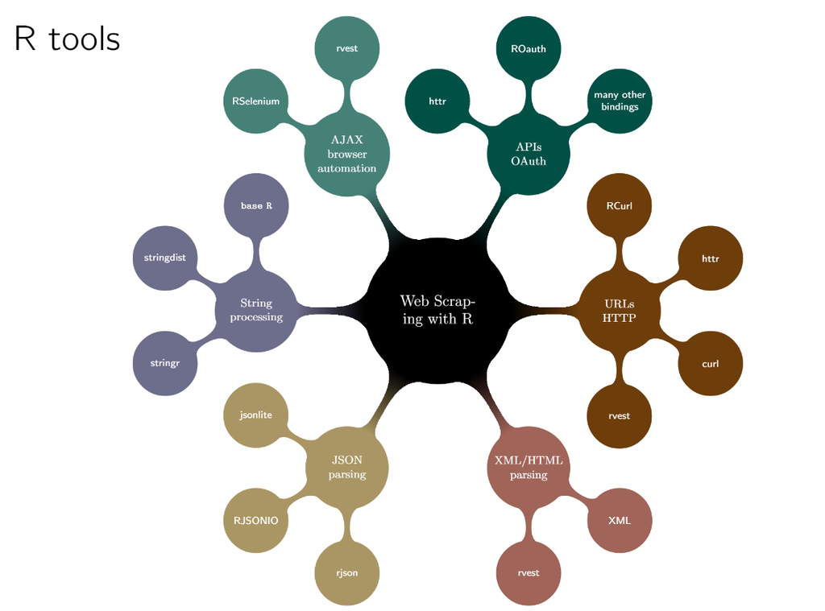

## Automatic Data Pipeline

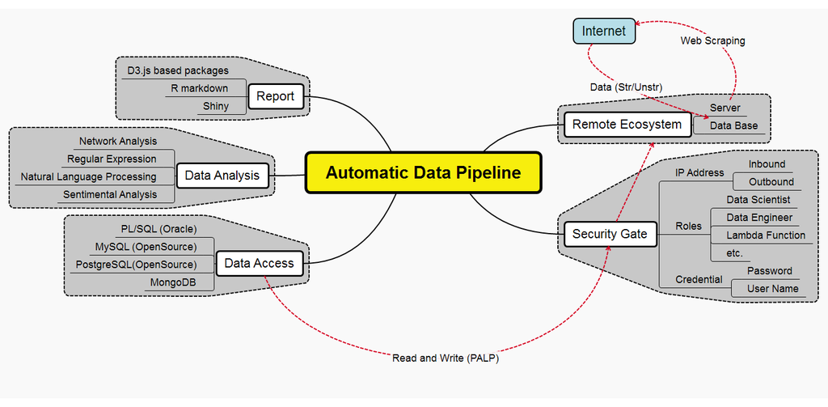

## `#yieldhero` Summary Statistics

- From 2016-07-28 to 2016-11-18
- There are 6914 tweets, 1930 origional tweets
- Products mentioned > 20 times
  - P1197AM
  - P0157AMX
  - P22T73R
  - P28T08R

## When is the best time to tweet?

- Total Tweet Counts

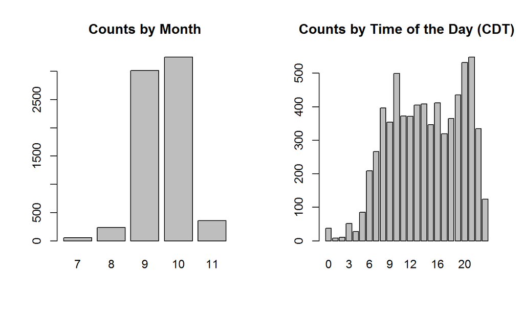

## When is the best time to tweet?

- Tweet and Re-tweet counts by time of the day

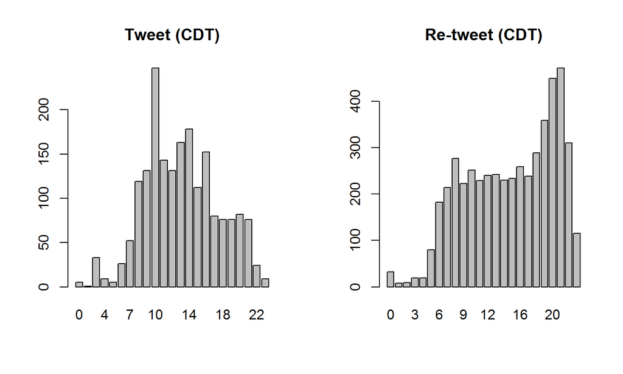

## Who to target?

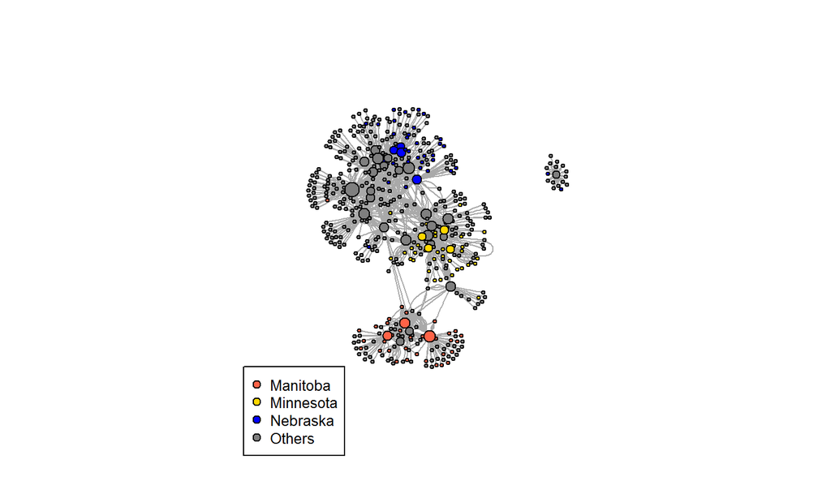

## Network

[interactive chart not shown]

## Who to target?

|  | name | size | state |
| --- | --- | --- | --- |
| 1 | PallasSeeds | 1 | Unknown |
| 2 | jrjr58 | 1 | Indiana |
| 3 | frenchrw | 1 | Texas |
| 4 | Pioneer_IL | 1 | Illinois |
| 5 | DarrenVanness | 1 | Nebraska |
| 6 | DeanSeeds_Jeff | 1 | Unknown |
| 7 | Mike_Eiberger | 1 | Unknown |
| 8 | CowboyCubby | 46 | Nebraska |
| 9 | DubbertRon | 1 | Unknown |
| 10 | farmerbuck1 | 1 | Minnesota |

[output cut: 472 more lines]

## Products Mentioned

[interactive chart not shown]

## Table of Products

|  | PROD_NM | size |
| --- | --- | --- |
| 1 | P1197AM | 48 |
| 2 | P0157AMX | 47 |
| 3 | P22T73R | 21 |
| 4 | P28T08R | 21 |
| 5 | P9188AM | 14 |
| 6 | P0506AM | 13 |
| 7 | P0589AMXT | 13 |
| 8 | P1311AMXT | 13 |
| 9 | P0157AM | 12 |
| 10 | P0339AMXT | 12 |

[output cut: 199 more lines]

## Is web scraping legal?

- No unambiguous yes or no in any country according to current jurisdiction
- So far, court cases (especially in the US) often dealt with commercial interest and often huge masses of data
  - eBay vs. Bidder's Edge
  - AP vs. Meltwater
  - Facebook vs. Pete Warden
  - United States vs. Aaron Swartz

## Recommendation for your work

- Encrypt sensitive personal identifiable information
- YOU take all the responsibility for your web scraping work
- If you publish data, do not commit copyright fraud
- If in doubt, ask the author/creator/provider of data for permission
- Consult current jurisdiction

## Trick: robots.txt

- What is robots.txt?

  > "Robots Exclusion Protocol", informal protocol to prohibit web robots from crawling content
- Located in the root directory of a website, e.g. http://baidu.com/robots.txt
- Documents which bot is allowed to crawl which resources (and which not)
- Not a technical barrier, but a sign that asks for compliance
- Syntax in robots.txt
- Scraping etiquette

## Data and Code

- All data are available in the package I am developing:

```r
library(devtools)
install_github("happyrabbit/DataScienceR")
library(DataScienceR)
```

- Slides and R code can be found here:
- http://scientistcafe.com/

"echoverse" for brand communication

## Discussion & Happy Holiday Season!